# Machine Learning Course Project

Jonathan Mallia Saturday, 11th March, 2017

## Background

Using devices such as Jawbone Up, Nike FuelBand, and Fitbit it is now possible to collect a large amount of data about personal activity relatively inexpensively. These type of devices are part of the quantified self movement - a group of enthusiasts who take measurements about themselves regularly to improve their health, to find patterns in their behavior, or because they are tech geeks. One thing that people regularly do is quantify how much of a particular activity they do, but they rarely quantify how well they do it. In this project, your goal will be to use data from accelerometers on the belt, forearm, arm, and dumbell of 6 participants. They were asked to perform barbell lifts correctly and incorrectly in 5 different ways. More information is available from the website here: http://groupware.les.inf.puc-rio.br/har (see the section on the Weight Lifting Exercise Dataset).

## Data

The training data for this project are available here: https://d396qusza40orc.cloudfront.net/predmachlearn/pml-training.csv

The test data are available here: https://d396qusza40orc.cloudfront.net/predmachlearn/pml-testing.csv

The data for this project come from this source: http://groupware.les.inf.puc-rio.br/har. If you use the document you create for this class for any purpose please cite them as they have been very generous in allowing their data to be used for this kind of assignment.

The classe variable contains 5 different ways barbell lifts were performed correctly and incorrectly:

Class A: exactly according to the specification Class B: throwing the elbows to the front Class C: lifting the dumbbell only halfway Class D: lowering the dumbbell only halfway Class E: throwing the hips to the front

## Objective

The goal of this project is to predict the manner in which people performed barbell lifts. This is the classe variable in the training set. You may use any of the other variables to predict with. You should create a report describing how you built your model, how you used cross validation, what you think the expected out of sample error is, and why you made the choices you did. You will also use your prediction model to predict 20 different test cases.

## Loading the data

```r
library(caret)
library(randomForest)
```

```r
library(rpart)
library(rpart.plot)

setwd("C:\\Users\\support\\Desktop\\Project")

set.seed(1000)

allData <- read.csv(".//Data//pml-training.csv", na.strings=c("NA","#DIV/0!",""))
newdata <- read.csv(".//Data//pml-testing.csv", na.strings=c("NA","#DIV/0!",""))
```

Check the size of the data set

```r
dim(allData)
```

```
## [1] 19622   160
```

Check the number of instances per predictors

```r
table(allData$classe)
```

```
##
##    A    B    C    D    E
## 5580 3797 3422 3216 3607
```

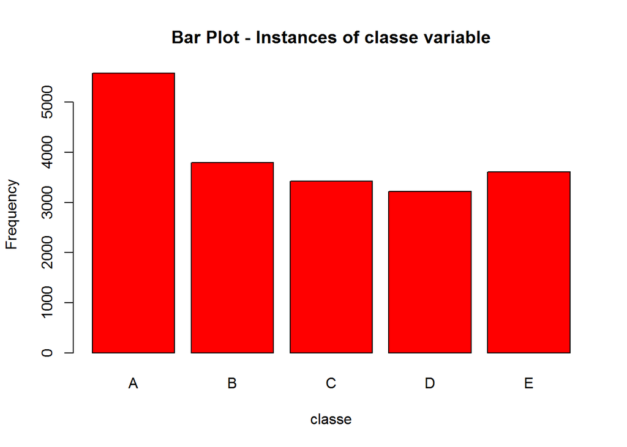

```r
plot(allData$classe, col="red", main="Bar Plot - Instances of classe variable", xlab="classe", ylab="Frequency")
```

```r
str(allData)
```

```
## 'data.frame':    19622 obs. of  160 variables:
##  $ RN                      : int  1 2 3 4 5 6 7 8 9 10 ...
##  $ user_name               : Factor w/ 6 levels "adelmo","carlitos",..: 2 2 2 2 2 2 2 2 2 2 ...
##  $ raw_timestamp_part_1    : int  1323084231 1323084231 1323084231 1323084232 1323084232 1323084232 1323084232 1323084232 1323084232 1323084232 ...
##  $ raw_timestamp_part_2    : int  788290 808298 820366 120339 196328 304277 368296 440390 484323 484434 ...
##  $ cvtd_timestamp          : Factor w/ 20 levels "02/12/2011 13:32",..: 9 9 9 9 9 9 9 9 9 9 ...
##  $ new_window              : Factor w/ 2 levels "no","yes": 1 1 1 1 1 1 1 1 1 1 ...
##  $ num_window              : int  11 11 11 12 12 12 12 12 12 12 ...
##  $ roll_belt               : num  1.41 1.41 1.42 1.48 1.48 1.45 1.42 1.42 1.43 1.45 ...
##  $ pitch_belt              : num  8.07 8.07 8.07 8.05 8.07 8.06 8.09 8.13 8.16 8.17 ...
##  $ yaw_belt                : num  -94.4 -94.4 -94.4 -94.4 -94.4 -94.4 -94.4 -94.4 -94.4 -94.4 ...
##  $ total_accel_belt        : int  3 3 3 3 3 3 3 3 3 3 ...
##  $ kurtosis_roll_belt      : num  NA NA NA NA NA NA NA NA NA NA ...
##  $ kurtosis_picth_belt     : num  NA NA NA NA NA NA NA NA NA NA ...
##  $ kurtosis_yaw_belt       : logi  NA NA NA NA NA NA ...
```

[output cut: 86 more lines]

## Cross validation

We used 70% of training set data to built a model, and use the rest to test the model predictions

```r
inTrain <- createDataPartition(y=allData$classe, p=0.7, list=FALSE)

training <- allData[inTrain,]
testing <- allData[-inTrain,]
```

## Data Cleaning

Firstly, the variables with near zero variance were excluded using the function nearZeroVar in the caret package

```r
near0var <- nearZeroVar(training)
training <- training[, -near0var]
```

Then columns with 50% ore more missing values were excluded

```r
cntlength <- sapply(training, function(x) { sum(!(is.na(x) | x == ""))})
nullcol <- names(cntlength[cntlength < 0.5 * length(training$classe)])
```

Descriptive columns like name were removed

```r
descriptcol <- c("RN", "user_name", "raw_timestamp_part_1", "raw_timestamp_part_2", "cvtd_timestamp", "new_window", "num_window")
excludecols <- c(descriptcol, nullcol)
```

The data set is then updated with the above changes

```r
training <- training[, !names(training) %in% excludecols]
```

## Prediction with Classification Trees

[figure not shown]

```r
modFitCT <- rpart(classe ~ ., data=training, method="class")

# Predicting:
predCT <- predict(modFitCT, testing, type = "class")

# Plot of the Decision Tree
rpart.plot(modFitCT, main="Classification Tree")
```

Test results on our testing data set

```r
confusionMatrix(predCT, testing$classe)
```

```
## Confusion Matrix and Statistics
##
##           Reference
## Prediction    A    B    C    D    E
##          A 1461  150   10   57   50
##          B   88  814  138   68   71
##          C   14  111  790  161   83
##          D   44   56   47  643   82
##          E   67    8   41   35  796
##
## Overall Statistics
##
##                Accuracy : 0.7653
##                  95% CI : (0.7543, 0.7761)
##     No Information Rate : 0.2845
##     P-Value [Acc > NIR] : < 2.2e-16
##
##                   Kappa : 0.7028
##  Mcnemar's Test P-Value : < 2.2e-16
##
## Statistics by Class:
##
##                      Class: A Class: B Class: C Class: D Class: E
## Sensitivity            0.8728   0.7147   0.7700   0.6670   0.7357
## Specificity            0.9366   0.9231   0.9241   0.9535   0.9686
## Pos Pred Value         0.8455   0.6904   0.6816   0.7374   0.8405
## Neg Pred Value         0.9488   0.9309   0.9501   0.9360   0.9421
## Prevalence             0.2845   0.1935   0.1743   0.1638   0.1839
## Detection Rate         0.2483   0.1383   0.1342   0.1093   0.1353
## Detection Prevalence   0.2936   0.2003   0.1969   0.1482   0.1609
## Balanced Accuracy      0.9047   0.8189   0.8470   0.8102   0.8521
```

## Prediction using Random Forest

```r
modFitRF <- randomForest(classe ~. , data=training, method="class")

# Predicting:
predRF <- predict(modFitRF, testing, type = "class")
```

Test results on testing data set

```r
confusionMatrix(predRF, testing$classe)
```

```
## Confusion Matrix and Statistics
##
##           Reference
## Prediction    A    B    C    D    E
##          A 1671    4    0    0    0
##          B    3 1134    7    0    0
##          C    0    1 1017   10    0
##          D    0    0    2  953    3
##          E    0    0    0    1 1079
##
## Overall Statistics
##
##                Accuracy : 0.9947
##                  95% CI : (0.9925, 0.9964)
##     No Information Rate : 0.2845
##     P-Value [Acc > NIR] : < 2.2e-16
##
##                   Kappa : 0.9933
##  Mcnemar's Test P-Value : NA
##
## Statistics by Class:
##
##                      Class: A Class: B Class: C Class: D Class: E
## Sensitivity            0.9982   0.9956   0.9912   0.9886   0.9972
## Specificity            0.9991   0.9979   0.9977   0.9990   0.9998
## Pos Pred Value         0.9976   0.9913   0.9893   0.9948   0.9991
## Neg Pred Value         0.9993   0.9989   0.9981   0.9978   0.9994
## Prevalence             0.2845   0.1935   0.1743   0.1638   0.1839
## Detection Rate         0.2839   0.1927   0.1728   0.1619   0.1833
## Detection Prevalence   0.2846   0.1944   0.1747   0.1628   0.1835
## Balanced Accuracy      0.9986   0.9968   0.9945   0.9938   0.9985
```

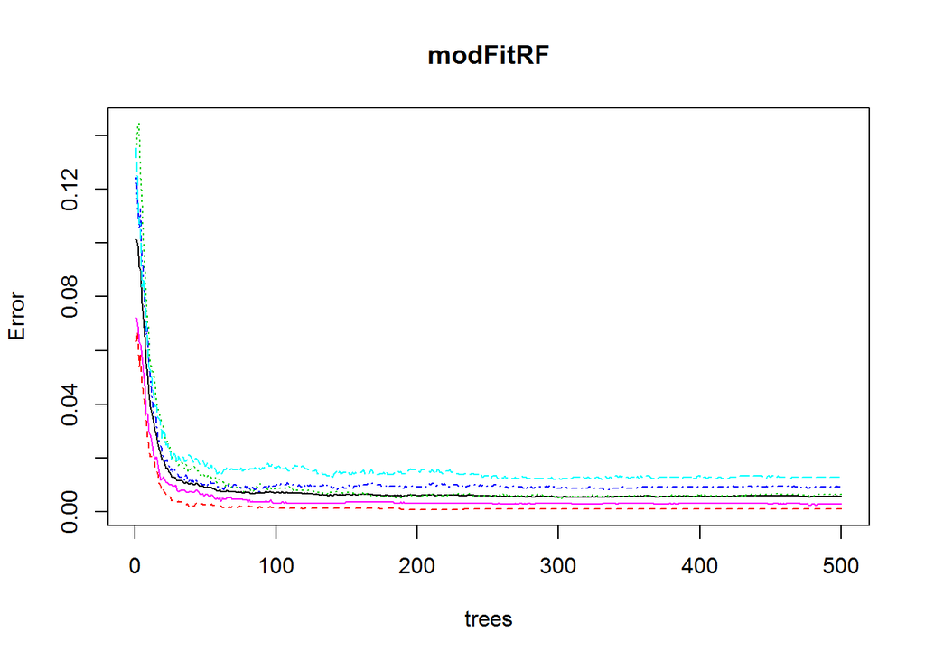

```r
plot(modFitRF)
```

## Prediction on the Test Data

The best model which is the Random Forest, was used to predict on the test data the way 20 participates performed the exercise.

```r
predict_final <- predict(modFitRF, newdata, type = "class")
print(predict_final)
```

```
##  1  2  3  4  5  6  7  8  9 10 11 12 13 14 15 16 17 18 19 20
##  B  A  B  A  A  E  D  B  A  A  B  C  B  A  E  E  A  B  B  B
## Levels: A B C D E
```